# Let’s party with the new ggparty package

The new package ggparty package is a lifesaver when you want yo show your tree models to others who surely don’t like the old base plot looking. And… You know, this is a helper post for my future self who have some memory problems. The ggparty package have a lot of functions to customize your tree plots much as you want so we’ll see the most important (for me and my future self) here.

Joshua Kunst http://jkunst.com/  
07-22-2019

## Introduction

Surely more than once you have needed to make a decision tree because:

- *Someone* or *they* asked you.
- Is an easy way to explain how the patterns in the data works, because trees are usually the first approach to machine learnig for a lot of us.
- Just you like them/it. Period.

If you have some experience with decision trees in R you know the most popular packages are `partykit` and `rpart`. In personal experience I always have much better results in `partykit` compared with `rpart` in terms of splits/structure. Besides the default plot is better IMHO, but that doesn’t mean is a good looking plot *hahaha*:

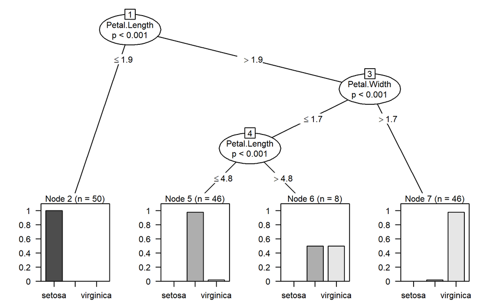

```r
library(partykit)

irisct <- ctree(Species ~ .,data = iris)

plot(irisct, gp = gpar(fontsize = 8))
```

That is 80’s flavor :D.

## Data, duh!

I pass my days in a chilean bank so usually work with data similar to the `germarcredit.csv`: a set of variables and a reponse varialbe indicating if the given account was in default or not.

```r
library(tidyverse)

credit <- read_csv(here::here("data/credit.csv"))

set.seed(123)

credit <- credit %>%
  group_by(bad) %>%
  sample_n(10000, replace = TRUE) %>%
  ungroup() %>%
  select(-id_client, -contains("phone"),  -contains("residence"),
         -profession_code, -payment_day, -marital_status, -sex,) %>%
  mutate(bad = ifelse(bad == 1, "bad", "good")) %>%
  mutate_if(is.character, as.factor)


glimpse(credit)
```

```
Rows: 20,000
Columns: 6
$ age                 <dbl> 38, 34, 44, 37, 36, 42, 28, 53, 69, 4...
$ months_in_the_job   <dbl> 24, 96, 264, 156, 192, 0, 0, 0, 0, 36...
$ flag_other_card     <fct> N, N, N, N, N, N, N, N, N, N, N, N, N...
$ personal_net_income <dbl> 887, 700, 968, 622, 702, 408, 207, 30...
$ quant_add_cards     <dbl> 0, 1, 0, 0, 0, 0, 0, 0, 0, 0, 0, 0, 0...
$ bad                 <fct> good, good, good, good, good, good, g...
```

## Back to the party

Let’s start with a simple model using the previous data and then plot it:

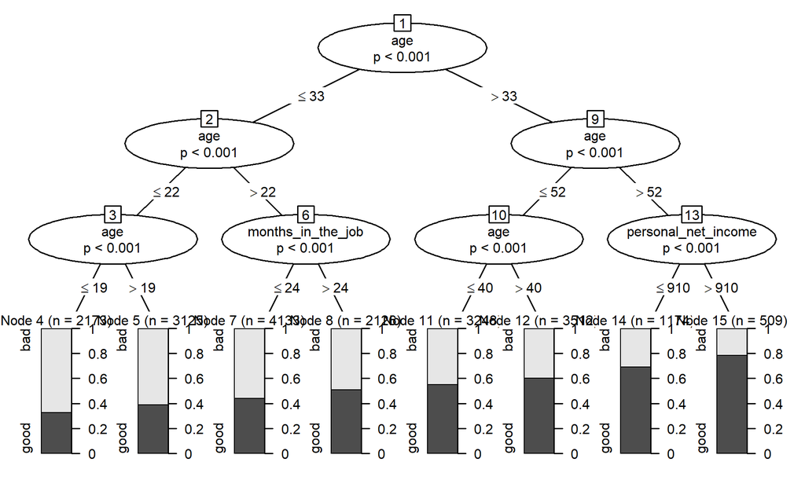

```r
tree <- ctree(bad ~ ., data = credit, control = ctree_control(maxdepth = 3))

plot(tree, gp = gpar(fontsize = 8))
```

Now the `ggparty`’s version:

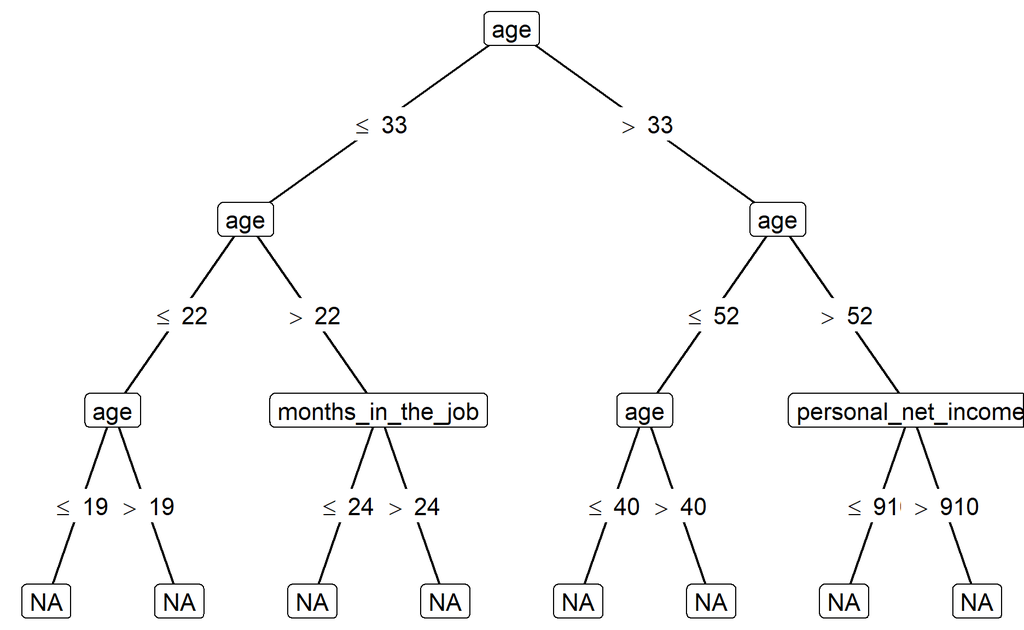

```r
library(ggparty)

# from the example of ?ggparty
ggparty(tree) +
  geom_edge() +
  geom_edge_label() +
  geom_node_label(aes(label = splitvar), ids = "inner") +
  geom_node_label(aes(label = info), ids = "terminal")
```

Oh! It looks promising but is kind of far of what `ggparty` can do.

The firsts questions about how `ggparty` works are:

> Where does **splitvar** or **info** come from? - Me.

> Why the terminal node show (in this case) **NA** - Me too.

And the answers are:

```r
the_magic <- as_tibble(ggparty(tree)$data)

glimpse(the_magic)
```

```
Rows: 15
Columns: 23
$ id                           <int> 1, 2, 3, 4, 5, 6, 7, 8, 9, 1...
$ x                            <dbl> 0.5000, 0.2500, 0.1250, 0.06...
$ y                            <dbl> 1.0, 0.8, 0.6, 0.4, 0.4, 0.6...
$ parent                       <int> NA, 1, 2, 3, 3, 2, 6, 6, 1, ...
$ birth_order                  <int> 0, 1, 1, 1, 2, 2, 1, 2, 2, 1...
$ breaks_label                 <I<list>>           NA, NA <= NA* ...
$ info                         <lgl> NA, NA, NA, NA, NA, NA, NA, ...
$ info_list                    <I<list>> c(907.11...., c(111.64.....
$ splitvar                     <chr> "age", "age", "age", NA, NA,...
$ level                        <dbl> 0, 1, 2, 3, 3, 2, 3, 3, 1, 2...
$ kids                         <int> 2, 2, 2, 0, 0, 2, 0, 0, 2, 2...
$ nodesize                     <int> 20000, 11557, 5298, 2173, 31...
$ p.value                      <dbl> 1.116958e-198, 1.709040e-25,...
$ horizontal                   <lgl> FALSE, FALSE, FALSE, FALSE, ...
$ x_parent                     <dbl> NA, 0.500, 0.250, 0.125, 0.1...
$ y_parent                     <dbl> NA, 1.0, 0.8, 0.6, 0.6, 0.8,...
$ nodedata_bad                 <list> [<good, good, good, good, g...
$ nodedata_age                 <list> [<38, 34, 44, 37, 36, 42, 2...
$ nodedata_months_in_the_job   <list> [<24, 96, 264, 156, 192, 0,...
$ nodedata_flag_other_card     <list> [<N, N, N, N, N, N, N, N, N...
$ nodedata_personal_net_income <list> [<887.00, 700.00, 968.00, 6...
$ nodedata_quant_add_cards     <list> [<0, 1, 0, 0, 0, 0, 0, 0, 0...
$ nodedata_fitted_nodes        <list> [<11, 11, 12, 11, 11, 12, 7...
```

In summary:

- The function `ggparty::ggparty` parse the tree (a `party` object) to a `data.frame` so you can use ggplot to show the parsed data.
- Each row is a node with the related informaction: the `id`, position (`x` and `y`), `parent`, `kids`, etc.
- And the magic keep going with the `nodedata_*` colums which have the data related in that node!

That’s why if you see the `info` column, you can notice is full of `NA`s and then the part `label = info` is showing us just the same `NA`s.

So, we can do? A lot! In fact, if you are if you are familiarized with `tibble`s and some `purrr` functions you now is easy operate list-columns.

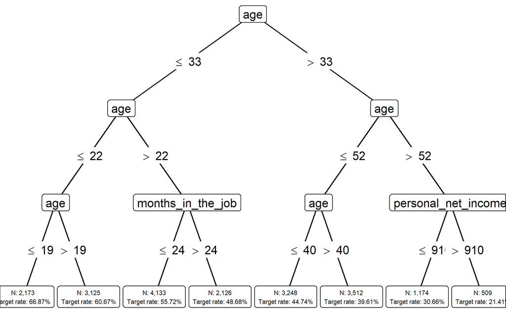

```r
library(scales) # for comma,percent function

ggparty(tree) +
  geom_edge() +
  geom_edge_label() +
  geom_node_label(aes(label = splitvar), ids = "inner") +
  geom_node_label(aes(label = info), ids = "terminal") +
  geom_node_label(
    aes(
      label = str_c(
        "N: ",
        comma(nodesize),
        "\nTarget rate: ",
        percent(map_dbl(nodedata_bad, ~ mean(.x == "bad")))
        )
      ),
  size = 2,
  ids = "terminal")
```

Mmm… Too much to do! Right?